# solar data preview

YD Hwang

2024-09-18

# mapping

These are monitoring locations.

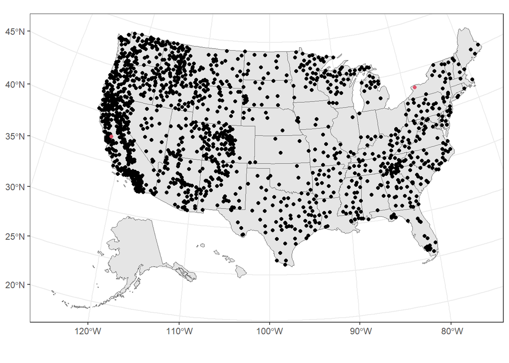

```r
usa <- usmap::us_map()

locs <- train.df %>% select(lat, long) %>% unique
projcrs <- "+proj=longlat +datum=WGS84 +no_defs +ellps=WGS84 +towgs84=0,0,0"
locs_sf <-  st_as_sf(x = locs, coords = c("long", "lat"), crs = projcrs)
ggplot() + geom_sf(data = usa)    +
  geom_sf(data = locs_sf) + xlab("") +
  geom_sf(data = locs_sf[1:2,], col = 2)
```

We have total of 8776379 rows, and 1538 locations. The number of available data points vary by locations: maximum 5737 and minimum 5

# one location

To see the data set associated with two locations, I chose two locations, marked by red dots in the previous plots. There are some missing data points. Since these are solar energy, you can see that they become zero after sunset.

```r
# choose the data portion for first location
(locs[1,])
```

```
## # A tibble: 1 × 2
##     lat  long
##   <dbl> <dbl>
## 1  37.7 -122.
```

```r
data_for_first_loc <- inner_join(train.df, locs[1,])
```

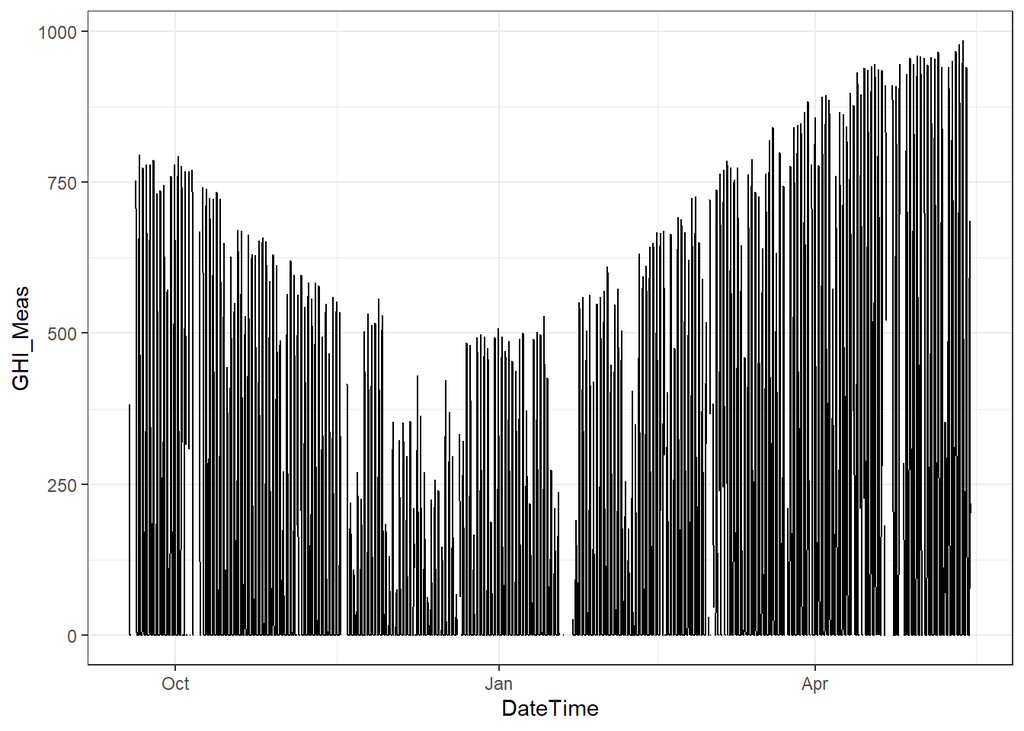

```r
data_for_first_loc <- data_for_first_loc %>%
  mutate(Month = month(DateTime))

ggplot(data = data_for_first_loc, aes(x = DateTime, y = GHI_Meas)) + geom_line()
```

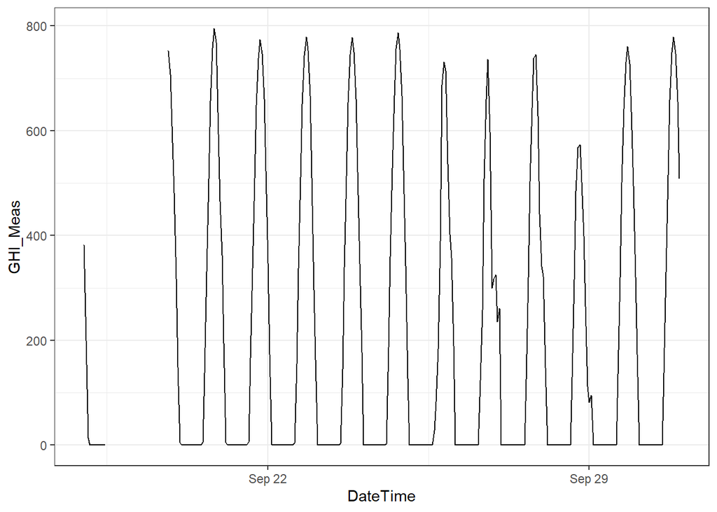

```r
ggplot(data = data_for_first_loc %>% filter(Month == 9 ), aes(x = DateTime, y = GHI_Meas)) + geom_line()
```

# another location

```r
# choose the data portion for first location
(locs[2,])
```

```
## # A tibble: 1 × 2
##     lat  long
##   <dbl> <dbl>
## 1  43.1 -78.4
```

```r
data_for_second_loc <- inner_join(train.df, locs[2,])
```

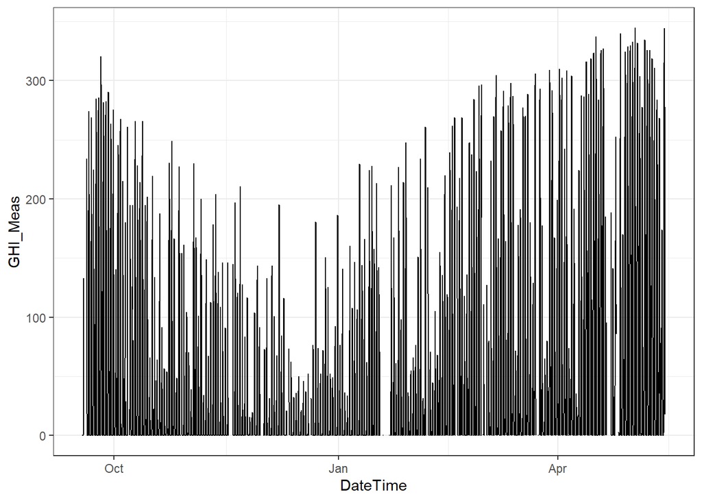

```r
data_for_second_loc <- data_for_second_loc %>%
  mutate(Month = month(DateTime))

ggplot(data = data_for_second_loc, aes(x = DateTime, y = GHI_Meas)) + geom_line()
```

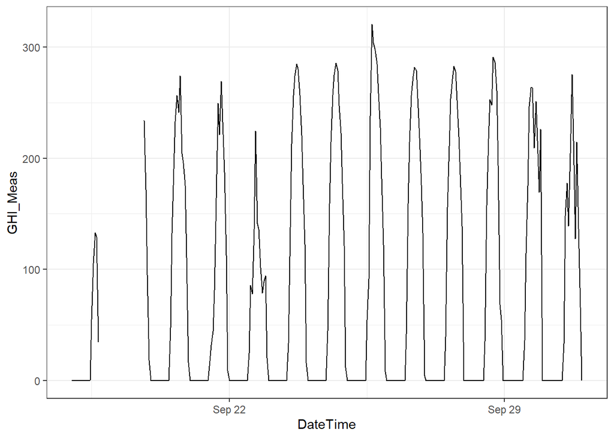

```r
ggplot(data = data_for_second_loc %>% filter(Month == 9 ), aes(x = DateTime, y = GHI_Meas)) + geom_line()
```

# possible modeling ideas

## Review 1

My previous work (AOAS 2018) considered the following.

$$\begin{eqnarray}
y_{it} &=& \beta_{0i} + \beta_{1i} x_{1it} + \beta_{2i} x_{2it}
+ \epsilon_{it} \\
\boldsymbol{\beta} &\sim& f(\boldsymbol{\beta}|
\boldsymbol{\theta} ) \\
\boldsymbol{\theta} &\sim& g(\boldsymbol{\theta}),
\end{eqnarray}$$
where $\boldsymbol{\beta} = (\beta_{1i}, \beta_{2i})$, and I use a simple spatial model for $f(\boldsymbol{\beta}| \boldsymbol{\theta})$. Here, $x_{1it}$ $x_{2it}$ are the NWP model output (SREF and NAM) for GHI. This is simple model, but the data set is very large (2GB in binary) So we proposed a way to handle the data set without communicating or merging (and writing). 2Gb is not small, but this data set is from 6+ years ago it was considered very large back then.

## Review 2

Another work (Stat. Sinica 2022) considered the following.
$$\begin{eqnarray}
y(\cdot) \sim |z(\cdot) \sim \mathcal{GP}( \mu_k, \sigma_k^2
\Phi_{\gamma_k}(\cdot, \cdot)), k=1,\ldots,K,
Pr(z = k) = g_{k}(x;\rho_k), k = 1,\ldots,K,
\end{eqnarray}$$
where $\mu_k(\cdot), \sigma_k^2, \Phi_{\gamma_k}$ are the mean, variance, and stationary correlation function of the $k$th GP, and $g_k(x, \rho_k)$ is the probability that $z(x) = k$ with unknown parameter $\rho_k$ with $\sum_{k} g_k(x;\rho_k) = 1$ for any $x$. In this work, we did not consider the SREF or NAM; we focused on the spatial components only.

## Possible direction

Although we only have two NWP in this case study, it is often the case where you have multiple outputs, i.e., $x_{ijt}, j = 1,\ldots,J$. Or $x_{it}(\xi)$, $\xi \sim \pi_{\xi}$. Here, $\xi$ is the unknown parameter for the computer model.
$$\begin{eqnarray}
y_{it} &=& \beta_{0} + \sum_{j=1}{J} \alpha_{j} x_{jit} +
\epsilon_{it} \\
\alpha_j \sim \pi_{\alpha}
\end{eqnarray}$$
with $\sum_{j=1}^{J} \alpha(s_i)$ for any $s_i$. When the setup with $\xi$ is considered, one can view this as an “ensemble” of the model outputs, and we are trying to find an optimal weighting scheme. We can set up the model with general $J$ combination, but can argue two model outputs can be considered as a special case.